# Underweight in Bangladeshi infants aged 6-13 months

Dataset 6: Bangladesh growth monitoring and promotion survey

RSR feasibility analysis

2026-08-03

# Introduction

The data come from a cross-sectional household survey in rural Bangladesh that compared two ways of delivering growth monitoring and promotion (GMP): sessions held at a community clinic (“facility-based”) and sessions held in the community/home (“home-based”). Caregivers of 3038 young children across six upazilas were interviewed and the children were weighed and measured (source paper: PLOS ONE, e0324918). Underweight — weight-for-age more than two standard deviations below the WHO reference median — is the indicator plotted on the child’s growth card and the one that triggers referral, so it is the binary outcome most directly connected to what a growth-monitoring programme is supposed to detect.

**Aim.** Among rural Bangladeshi infants aged 6-13 months, we examined which of GMP delivery model, child sex, child age, mother’s age, mother’s schooling, household asset tertile, NGO membership and toilet quality are independently associated with the odds of being underweight, mutually adjusting for the others.

This is a *Purpose 3* analysis: several predictors are of interest and the question is which remain associated with the outcome after mutual adjustment.

# Methods

**Data source.** Cross-sectional survey of 3038 caregiver-child pairs in six rural upazilas of Bangladesh. The study sampled 60 community-clinic catchment areas, arranged as matched pairs, one area of each pair receiving facility-based and the other home-based GMP. The file supplied for this catalogue contains one row per child.

*Weight-for-age Z-score is excluded by construction.* The outcome is a deterministic cut of `weight_for_age_z`, so including the parent Z-score would give complete separation and meaningless coefficients. `weight_for_height_z` is also excluded because it is computed from the identical weight measurement, and `height_for_age_z` / `stunted` because they are built from the same child’s length measurement and overlap heavily with the outcome (436 children are both underweight and stunted).

*Delivery model versus sub-district.* `delivery_model` and `sub_district` are almost the same variable: only 8 of 3038 records (0.3%) sit in a sub-district whose other children received the alternative model. Fitting both together yields variance inflation factors of roughly 96 and 103 and inflates the delivery-model standard error about nine-fold. We kept `delivery_model`, the substantive programme exposure, and excluded `sub_district`; the cost is that geographic variation between the six upazilas is absorbed into the delivery-model coefficient.

*Near-constant variables dropped.* `mother_occupation` is 97.5% “housewife” and `religion_muslim` is 97.8% Muslim; both were left out of the main model and are shown in a sensitivity fit in the feasibility notes.

**Statistical analysis.** Logistic regression via `glm(family = binomial)`, justified because the outcome is binary. We fitted a univariable model for each predictor first, then a single multivariable model containing all of them. Predictors were chosen in advance on subject-matter grounds, not by significance. Estimates are reported as odds ratios with 95% confidence intervals; significance threshold 0.05. Model fit is summarised with AIC and the events-per-parameter ratio. Assumptions were checked with `performance::check_model()`. Analysis used R version 4.6.0 (2026-04-24) with tidyverse, gtsummary and performance.

**Missing data.** Complete-case analysis: 3033 of 3038 rows were analysed (5 dropped), of whom 622 were underweight.

# Results

## Sample characteristics

**Table 1. Sample characteristics, by underweight status.**

| **Characteristic** | **N** | **Overall** N = 3,033<sup>1</sup> | **Not underweight** N = 2,411<sup>1</sup> | **Underweight** N = 622<sup>1</sup> |
| --- | --- | --- | --- | --- |
| Growth-monitoring delivery model | 3,033 |  |  |  |
| Facility-based |  | 1,518 (50%) | 1,207 (50%) | 311 (50%) |
| Home-based |  | 1,515 (50%) | 1,204 (50%) | 311 (50%) |
| Child's sex | 3,033 |  |  |  |
| Male |  | 1,546 (51%) | 1,201 (50%) | 345 (55%) |
| Female |  | 1,487 (49%) | 1,210 (50%) | 277 (45%) |
| Child's age (months) | 3,033 | 9.70 (8.50, 11.30) | 9.60 (8.40, 11.20) | 10.00 (8.70, 11.50) |
| Mother's age (years) | 3,033 | 25.0 (21.0, 30.0) | 25.0 (21.0, 30.0) | 26.0 (21.0, 31.0) |
| Mother's schooling (years) | 3,033 | 6.0 (4.0, 9.0) | 6.0 (4.0, 9.0) | 5.0 (2.0, 8.0) |
| Household asset index tertile | 3,033 |  |  |  |
| Lowest |  | 1,022 (34%) | 748 (31%) | 274 (44%) |
| Middle |  | 1,018 (34%) | 806 (33%) | 212 (34%) |
| Highest |  | 993 (33%) | 857 (36%) | 136 (22%) |
| Mother is an NGO member | 3,033 | 1,567 (52%) | 1,228 (51%) | 339 (55%) |
| Improved toilet facility | 3,033 | 2,832 (93%) | 2,253 (93%) | 579 (93%) |

<sup>1</sup> n (%); Median (Q1, Q3)

20.5% of children (622 of 3033) were underweight. Underweight children come disproportionately from the lowest asset tertile and have mothers with fewer years of schooling and, notably, higher maternal age — a crude contrast that turns out not to survive adjustment.

## Exploratory figure

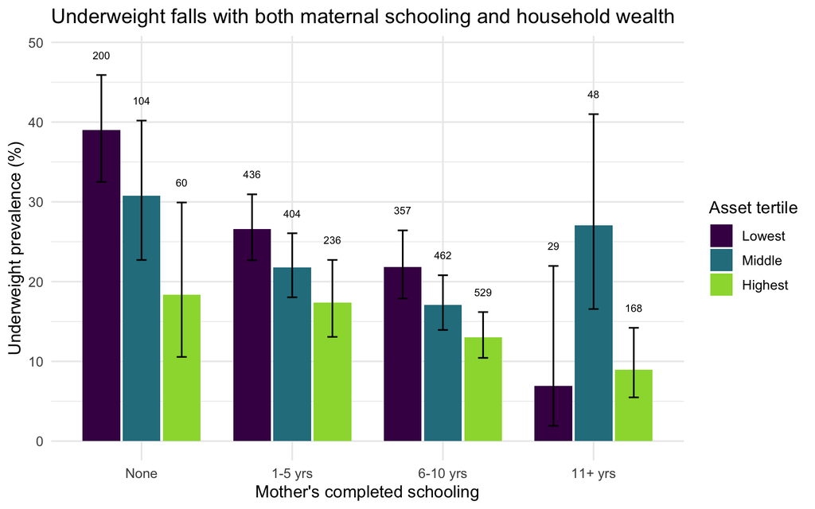

Figure 1. Prevalence of underweight by mother’s completed schooling (grouped) and household asset tertile. Error bars are 95% Wilson confidence intervals; numbers above the bars are group sizes.

## Univariable models

| **Characteristic** | **N** | **OR** | **95% CI** | **p-value** |
| --- | --- | --- | --- | --- |
| Growth-monitoring delivery model | 3,033 |  |  |  |
| Facility-based |  | — | — |  |
| Home-based |  | 1.00 | 0.84, 1.20 | >0.9 |
| Child's sex | 3,033 |  |  |  |
| Male |  | — | — |  |
| Female |  | 0.80 | 0.67, 0.95 | 0.012 |
| Child's age (months) | 3,033 | 1.10 | 1.05, 1.16 | <0.001 |
| Mother's age (years) | 3,033 | 1.03 | 1.02, 1.05 | <0.001 |
| Mother's schooling (years) | 3,033 | 0.90 | 0.87, 0.92 | <0.001 |
| Household asset index tertile | 3,033 |  |  |  |
| Lowest |  | — | — |  |
| Middle |  | 0.72 | 0.58, 0.88 | 0.002 |
| Highest |  | 0.43 | 0.34, 0.54 | <0.001 |
| Mother is an NGO member | 3,033 |  |  |  |
| No |  | — | — |  |
| Yes |  | 1.15 | 0.97, 1.38 | 0.11 |
| Improved toilet facility | 3,033 |  |  |  |
| No |  | — | — |  |
| Yes |  | 0.94 | 0.67, 1.35 | 0.7 |

Abbreviations: CI = Confidence Interval, OR = Odds Ratio

Unadjusted, household wealth is the strongest predictor: children in the highest asset tertile have OR 0.433 (95% CI 0.344 to 0.543) compared with the lowest (p < 0.001), a reduction of well over half in the odds of being underweight, with the middle tertile at OR 0.718 (95% CI 0.585 to 0.881) (p = 0.002). Each additional year of maternal schooling is associated with OR 0.897 (95% CI 0.874 to 0.920) (p < 0.001). Each additional year of *mother’s age* is associated with higher odds, OR 1.031 (95% CI 1.016 to 1.047) (p < 0.001). Older children have higher odds, OR 1.104 (95% CI 1.050 to 1.161) per month (p < 0.001), and girls lower odds than boys, OR 0.797 (95% CI 0.667 to 0.951) (p = 0.012). The programme variable is flat: home-based areas show OR 1.002 (95% CI 0.840 to 1.196) (p = 0.978), an odds ratio essentially equal to 1.

## Why adjustment is needed

**Mother’s age** is the clearest confounded variable in this analysis, and the mechanism is concrete: female schooling has expanded rapidly across birth cohorts in Bangladesh, so a 35-year-old mother in this sample has systematically fewer years of education than a 20-year-old, and low maternal education is strongly associated with underweight. The crude maternal-age odds ratio is therefore largely a maternal-education effect wearing a different label. **Household asset tertile** confounds the schooling association in the same way and is confounded by it in return: wealthier households educate daughters longer and also buy more and better food, so neither crude estimate can be read on its own. **Improved toilet facility** is a third: latrine ownership is concentrated in the upper asset tertiles, and poor sanitation causes the enteric disease that suppresses weight gain, so its crude odds ratio cannot be separated from wealth without adjustment. **Child age** must be held constant on structural grounds, since weight-for-age declines across the observed window.

## Multivariable model

| **Characteristic** | **OR** | **95% CI** | **p-value** |
| --- | --- | --- | --- |
| Growth-monitoring delivery model |  |  |  |
| Facility-based | — | — |  |
| Home-based | 1.00 | 0.83, 1.22 | >0.9 |
| Child's sex |  |  |  |
| Male | — | — |  |
| Female | 0.79 | 0.66, 0.95 | 0.011 |
| Child's age (months) | 1.11 | 1.06, 1.17 | <0.001 |
| Mother's age (years) | 1.01 | 1.00, 1.03 | 0.10 |
| Mother's schooling (years) | 0.92 | 0.89, 0.95 | <0.001 |
| Household asset index tertile |  |  |  |
| Lowest | — | — |  |
| Middle | 0.78 | 0.64, 0.97 | 0.024 |
| Highest | 0.53 | 0.41, 0.67 | <0.001 |
| Mother is an NGO member |  |  |  |
| No | — | — |  |
| Yes | 1.06 | 0.87, 1.29 | 0.6 |
| Improved toilet facility |  |  |  |
| No | — | — |  |
| Yes | 1.34 | 0.94, 1.95 | 0.11 |

Abbreviations: CI = Confidence Interval, OR = Odds Ratio

Model fit

| Statistic | Value |
| --- | --- |
| AIC | 2971.1 |
| Null deviance | 3077.7 |
| Residual deviance | 2951.1 |
| Events (underweight) | 622 |
| Non-events | 2,411 |
| Model parameters (excl. intercept) | 9 |
| Events per parameter | 69.1 |

AIC is 2971.1, with residual deviance 2951.1 against a null deviance of 3077.7. With 622 events and 9 estimated parameters there are 69.1 events per parameter, far above the conventional minimum of 10, so no coefficient is resting on a sparse cell.

Holding the other predictors constant, children in the highest asset tertile have OR 0.527 (95% CI 0.413 to 0.670) of being underweight relative to the lowest tertile (p < 0.001), and those in the middle tertile OR 0.784 (95% CI 0.635 to 0.967) (p = 0.024). Each extra year of maternal schooling is associated with OR 0.918 (95% CI 0.892 to 0.945) (p < 0.001), each additional month of child age with OR 1.111 (95% CI 1.056 to 1.170) (p < 0.001), and girls with OR 0.791 (95% CI 0.660 to 0.947) relative to boys (p = 0.011). Mother’s age is no longer associated with the outcome, OR 1.013 (95% CI 0.997 to 1.029) (p = 0.102). Adjusted for household circumstances, home-based GMP areas show OR 1.003 (95% CI 0.828 to 1.216) (p = 0.972).

## Unadjusted versus adjusted

**Table 2. Unadjusted and adjusted odds ratios.**

| **Characteristic** | **Unadjusted** **N** | **Unadjusted** **OR** | **Unadjusted** **95% CI** | **Unadjusted** **p-value** | **Adjusted** **OR** | **Adjusted** **95% CI** | **Adjusted** **p-value** |
| --- | --- | --- | --- | --- | --- | --- | --- |
| Growth-monitoring delivery model | 3,033 |  |  |  |  |  |  |
| Facility-based |  | — | — |  | — | — |  |
| Home-based |  | 1.00 | 0.84, 1.20 | >0.9 | 1.00 | 0.83, 1.22 | >0.9 |
| Child's sex | 3,033 |  |  |  |  |  |  |
| Male |  | — | — |  | — | — |  |
| Female |  | 0.80 | 0.67, 0.95 | 0.012 | 0.79 | 0.66, 0.95 | 0.011 |
| Child's age (months) | 3,033 | 1.10 | 1.05, 1.16 | <0.001 | 1.11 | 1.06, 1.17 | <0.001 |
| Mother's age (years) | 3,033 | 1.03 | 1.02, 1.05 | <0.001 | 1.01 | 1.00, 1.03 | 0.10 |
| Mother's schooling (years) | 3,033 | 0.90 | 0.87, 0.92 | <0.001 | 0.92 | 0.89, 0.95 | <0.001 |
| Household asset index tertile | 3,033 |  |  |  |  |  |  |
| Lowest |  | — | — |  | — | — |  |
| Middle |  | 0.72 | 0.58, 0.88 | 0.002 | 0.78 | 0.64, 0.97 | 0.024 |
| Highest |  | 0.43 | 0.34, 0.54 | <0.001 | 0.53 | 0.41, 0.67 | <0.001 |
| Mother is an NGO member | 3,033 |  |  |  |  |  |  |
| No |  | — | — |  | — | — |  |
| Yes |  | 1.15 | 0.97, 1.38 | 0.11 | 1.06 | 0.87, 1.29 | 0.6 |
| Improved toilet facility | 3,033 |  |  |  |  |  |  |
| No |  | — | — |  | — | — |  |
| Yes |  | 0.94 | 0.67, 1.35 | 0.7 | 1.34 | 0.94, 1.95 | 0.11 |

Abbreviations: CI = Confidence Interval, OR = Odds Ratio

**One predictor changed significance status, and it is the most instructive result in the table.** Mother’s age went from OR 1.031 (95% CI 1.016 to 1.047) (p < 0.001) to OR 1.013 (95% CI 0.997 to 1.029) (p = 0.102) — on the log-odds scale, 58% of the crude association vanished once maternal schooling and household wealth were held constant. Older mothers do not have more underweight children; poorer, less-educated mothers do, and they happen to be older.

**Two predictors moved substantially toward the null but stayed significant.** The highest-versus-lowest asset odds ratio went from OR 0.433 (95% CI 0.344 to 0.543) to OR 0.527 (95% CI 0.413 to 0.670) (23% attenuation on the log-odds scale), and maternal schooling from OR 0.897 (95% CI 0.874 to 0.920) to OR 0.918 (95% CI 0.892 to 0.945) (21%). This is the reciprocal confounding anticipated above: each was carrying part of the other’s association.

**One moved away from the null without reaching significance.** Improved toilet reversed direction from OR 0.944 (95% CI 0.672 to 1.354) (p = 0.748) to OR 1.343 (95% CI 0.943 to 1.949) (p = 0.111). Once wealth is held constant, the households that still lack a latrine are not the poorest ones, and whatever crude protection sanitation appeared to offer was wealth all along.

**Three predictors barely moved**: delivery model (OR 1.002 (95% CI 0.840 to 1.196) to OR 1.003 (95% CI 0.828 to 1.216)), child sex (OR 0.797 (95% CI 0.667 to 0.951) to OR 0.791 (95% CI 0.660 to 0.947)) and child age (OR 1.104 (95% CI 1.050 to 1.161) to OR 1.111 (95% CI 1.056 to 1.170)). Sex and age are not determined by household circumstances, so there is no confounding to remove; delivery model was allocated to matched-pair areas, which is presumably why the arms are balanced. None of this is a collinearity artefact — all variance inflation factors are below 1.3.

## Diagnostics

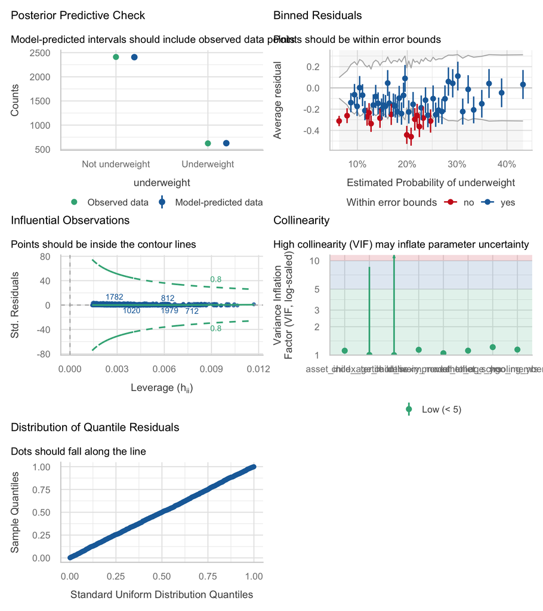

Variance inflation factors

| Term | VIF |
| --- | --- |
| delivery_model | 1.14 |
| child_sex | 1.00 |
| child_age_months | 1.00 |
| mother_age_yrs | 1.12 |
| mother_schooling_yrs | 1.21 |
| asset_index_tertile | 1.11 |
| ngo_member | 1.14 |
| improved_toilet | 1.05 |

For a logistic model only some panels apply; homogeneity of variance and normality of residuals do not and should be ignored.

*Binned residuals* is the panel that matters, and the model does not pass it cleanly: only 75% of bins fall inside the error bounds against a nominal 95%. Refitting with quadratic terms for child age, mother’s age and schooling gives 65% and a *worse* AIC (2976.6 versus 2971.1), so a wrong functional form is not the explanation. The likelier cause is the unmodelled clustering described under limitations, which produces extra-binomial variation of exactly this kind. We retain the linear specification and report the caveat rather than chasing a transformation that does not help.

*Collinearity* is unproblematic as specified, all VIFs under 1.3 — but only because `sub_district` was deliberately excluded. The *posterior predictive check* matches the observed outcome distribution, and no observation lies outside the Cook’s-distance contours in the *influential observations* panel. With 69.1 events per parameter the model is well clear of the sparse-data regime.

# Discussion

**Limitations.**

*The outcome is truncated by design, so prevalence is understated.* The source paper states that children with severe stunting, wasting or underweight were excluded on ethical grounds so they could be referred for treatment. The shipped file nonetheless contains 120 children with weight-for-age below -3 and 203 with height-for-age below -3, so the exclusion was either incomplete or applied on a different criterion. For a binary outcome this bites hard: the children who would most clearly be classified as underweight have been selectively thinned, so the 20.5% prevalence reported here understates the true burden and every odds ratio is attenuated toward 1. This is a documented contradiction in the source, not something we could repair.

*Clustering cannot be modelled.* Delivery model is an **area-level** exposure assigned to whole upazilas — six of them — and the survey sampled 60 community-clinic catchment areas as matched pairs. Children in the same catchment share fieldworkers, scales, clinics and food markets, so their outcomes are correlated. The file contains no clinic or cluster identifier, so neither random effects nor cluster-robust standard errors can be fitted, and the confidence interval on `delivery_model` is too narrow. `sub_district` cannot substitute as a cluster variable because it is collinear with the exposure.

*Age definition is inconsistent in the source.* The paper’s abstract says children “under one year”, its methods say 6-23 months, and the data run 6.0 to 13.0 months. We describe the observed range only; underweight prevalence over a full 6-23-month window would be higher.

*Design and residual confounding.* Cross-sectional data give associations, not effects. Birth weight, gestational age, maternal height and BMI, breastfeeding and complementary feeding practice, and recent illness are all absent and all cause low weight-for-age.

*Sparse and dropped variables.* `mother_occupation` and `religion_muslim` were excluded as near-constant, so nothing can be said about either.

**Future work.** A longitudinal design with cluster identifiers, birth anthropometry and feeding data, and without the severe-malnutrition exclusion, would be needed for any causal statement about GMP delivery and underweight.

# Feasibility notes

*Not part of a student report.*

**Verdict: the strongest of the three binary outcomes, and the one to recommend if a student wants a logistic model.**

1. **The crude-versus-adjusted section actually has content**, which is not true of `stunted`. Mother’s age crosses from significant to null (1.031, p < 0.001 to 1.013, p = 0.102); the highest asset tertile attenuates from 0.433 to 0.527; maternal schooling from 0.897 to 0.918; improved toilet flips from 0.944 to 1.343. There is a real story to write.
2. **The outcome must be derived, so the brief has to say so explicitly**, along with the `<=` versus `<` convention. Students who silently use a different cut will report a different event count (622 versus 614).
3. **`weight_for_age_z` must never appear as a predictor** — it defines the outcome and produces complete separation. `weight_for_height_z` shares the identical weight measurement and is nearly as bad. This is the single most likely student error on this outcome and needs to be stated in the brief.
4. **`delivery_model` versus `sub_district`.** 99.7% overlap (8 discordant records out of 3038); together, VIFs around 96 and 103.
5. **Fitting is clean apart from binned residuals.** 69.1 events per parameter, no separation, no sparse cells, VIFs under 1.3. The binned-residual check fails the nominal 95% standard (75% inside bounds) and quadratic terms make it worse, so it should be reported as unmodelled clustering rather than treated as a fixable specification problem.
6. **Near-constant predictors.** Sensitivity fit adding them back:

Near-constant predictors, added back (odds ratios)

n = 77 non-housewives, 66 non-Muslim households

| term | estimate | conf.low | conf.high | p.value |
| --- | --- | --- | --- | --- |
| mother_occupationOther | 1.646 | 0.923 | 2.825 | 0.079 |
| religion_muslimMuslim | 1.907 | 0.946 | 4.396 | 0.095 |

Very wide intervals resting on tiny comparison groups; shown only to justify dropping them.

7. **Overlap with `weight_for_age_z`.** Same measurement, dichotomised. If the assignment does not require a logistic model, the continuous version is strictly better powered.